# Отчёт по лабораторной работе №15

Настройка сетевого журналирования

Бызова Мария Олеговна

2025-12-05

# Цель работы

## Цель работы

Целью данной лабораторной работы является приобретение навыков по работе с журналами системных событий.

# Задание

## Задание

1. Настроить сервер сетевого журналирования событий.
2. Настроить клиент для передачи системных сообщений в сетевой журнал на сервере.
3. Просмотреть журналы системных событий с помощью нескольких программ.
4. Написать скрипты для Vagrant, фиксирующие действия по установке и настройке сетевого сервера журналирования.

# Выполнение лабораторной работы

## Выполнение лабораторной работы

На сервере создан файл конфигурации для сетевого хранения журналов в каталоге `/etc/rsyslog.d/` (рис. 1).

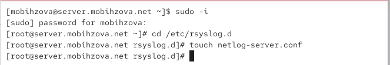

Рисунок 1: Создание файла конфигурации netlog-server.conf на сервере

## Выполнение лабораторной работы

В файл `/etc/rsyslog.d/netlog-server.conf` добавлены строки для включения приёма записей журнала по TCP-порту 514 (рис. 2).

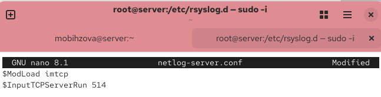

Рисунок 2: Конфигурация сервера rsyslog для приёма сообщений по TCP-порту 514

## Выполнение лабораторной работы

Проверка показывает, что служба rsyslog прослушивает TCP-порт для приёма сетевых логов (рис. 4).

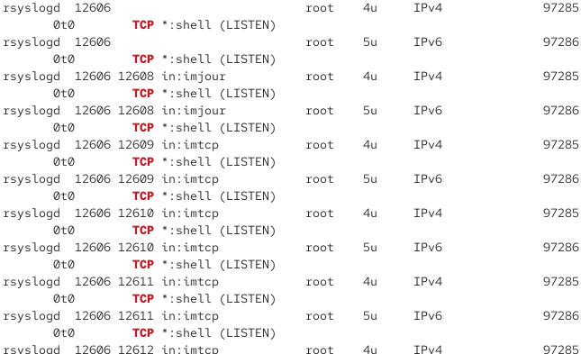

Рисунок 4: Проверка прослушивания портов, связанных с rsyslog

## Выполнение лабораторной работы

Добавлено разрешение для TCP-порта 514 в настройках файрвола (рис. 5).

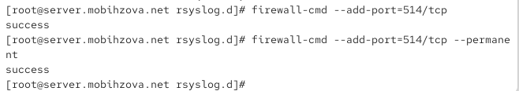

Рисунок 5: Настройка межсетевого экрана для приёма сообщений по TCP-порту 514

## Выполнение лабораторной работы

На клиенте создан файл конфигурации для сетевого хранения журналов в каталоге `/etc/rsyslog.d/` (рис. 6).

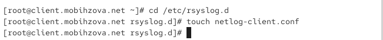

Рисунок 6: Создание файла конфигурации netlog-client.conf на клиенте

## Выполнение лабораторной работы

В файл `/etc/rsyslog.d/netlog-client.conf` добавлена строка для перенаправления всех системных сообщений на сервер журналирования (рис. 7).

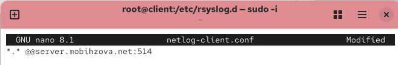

Рисунок 7: Конфигурация клиента для отправки сообщений на сервер rsyslog

## Выполнение лабораторной работы

Служба rsyslog перезапущена на клиенте для применения изменений конфигурации (рис. 8).

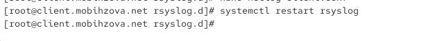

Рисунок 8: Перезапуск службы rsyslog на клиенте

## Выполнение лабораторной работы

На сервере выполнен просмотр журналов системных событий в реальном времени (рис. 9).

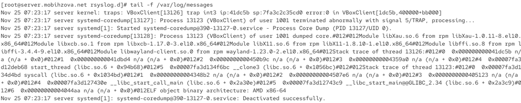

Рисунок 9: Просмотр журнала сообщений в реальном времени с помощью tail -f

## Выполнение лабораторной работы

Запущен графический монитор системы для просмотра системных процессов и ресурсов (рис. 10).

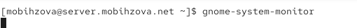

Рисунок 10: Запуск графического монитора системы gnome-system-monitor

## Выполнение лабораторной работы

Интерфейс графического монитора системы отображает список процессов и информацию об использовании системных ресурсов (рис. 11).

[figure not shown]

Рисунок 11: Интерфейс графического монитора системы с информацией о процессах

## Выполнение лабораторной работы

Установлены дополнительные утилиты для просмотра и анализа журналов (рис. 12).

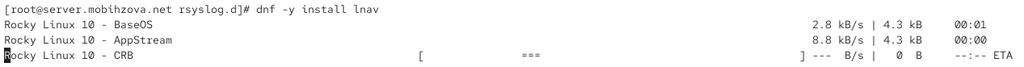

Рисунок 12: Установка утилиты lnav для анализа журналов

## Выполнение лабораторной работы

Установлены утилиты multitail и most для расширенного просмотра журналов (рис. 13).

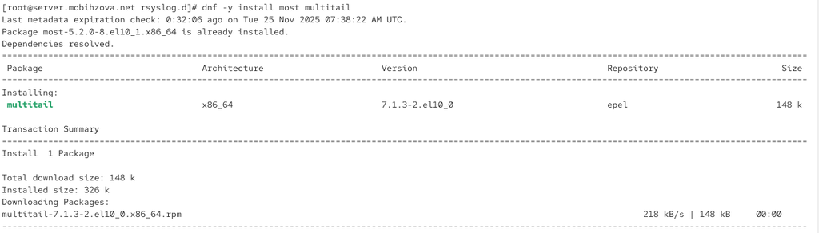

Рисунок 13: Установка утилит multitail и most для просмотра журналов

## Выполнение лабораторной работы

Выполнен просмотр журналов системных событий с помощью утилиты multitail (рис. 14).

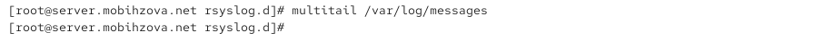

Рисунок 14: Просмотр журналов с помощью утилиты multitail

## Выполнение лабораторной работы

Отображено содержимое журналов системных событий с сообщениями о работе системы (рис. 15).

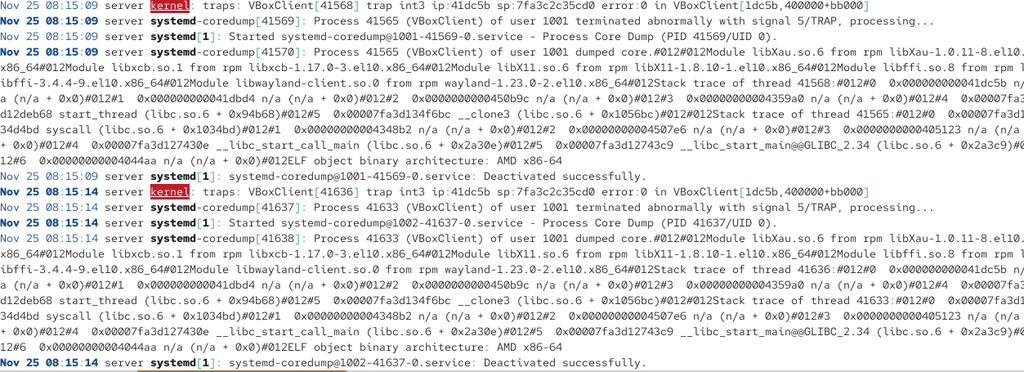

Рисунок 15: Содержимое журналов системных событий в multitail

## Выполнение лабораторной работы

Выполнена фильтрация журналов для просмотра только сообщений, связанных с клиентом (рис. 16).

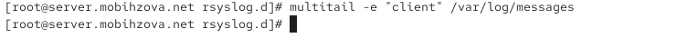

Рисунок 16: Фильтрация журналов для просмотра сообщений от клиента

## Выполнение лабораторной работы

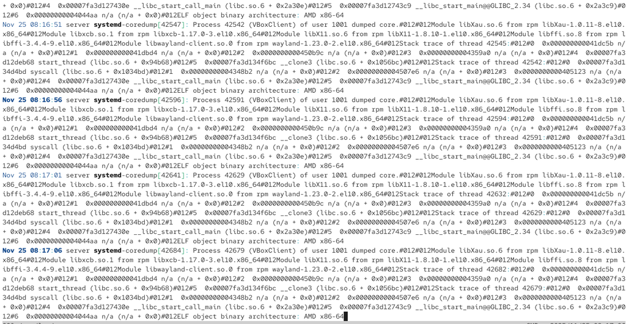

## Выполнение лабораторной работы

Создана структура каталогов для хранения конфигурации rsyslog на сервере (рис. 18).

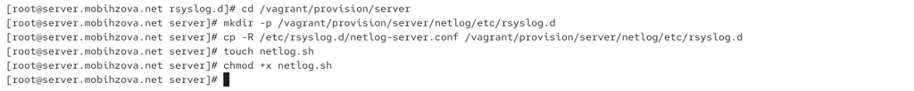

Рисунок 18: Создание каталогов и копирование конфигурационных файлов rsyslog на сервере

## Выполнение лабораторной работы

Создан скрипт автоматической настройки rsyslog для сервера (рис. 19).

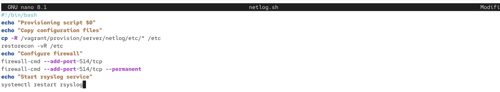

Рисунок 19: Скрипт netlog.sh для автоматической настройки rsyslog на сервере

## Выполнение лабораторной работы

Создана структура каталогов для хранения конфигурации rsyslog на клиенте (рис. 20).

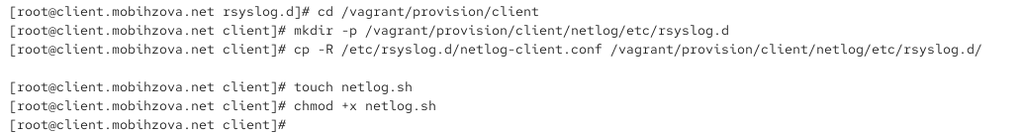

Рисунок 20: Создание каталогов и копирование конфигурационных файлов rsyslog на клиенте

## Выполнение лабораторной работы

Создан скрипт автоматической настройки rsyslog для клиента (рис. 21).

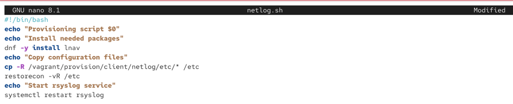

Рисунок 21: Скрипт netlog.sh для автоматической настройки rsyslog на клиенте

## Выполнение лабораторной работы

Добавлена конфигурация провижининга для сервера в Vagrantfile (рис. 22).

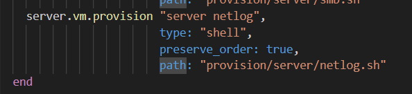

Рисунок 22: Настройка провижининга rsyslog сервера в Vagrantfile

## Выполнение лабораторной работы

Добавлена конфигурация провижининга для клиента в Vagrantfile (рис. 23).

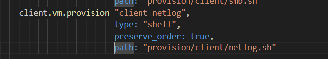

Рисунок 23: Настройка провижининга rsyslog клиента в Vagrantfile

# Выводы

## Выводы

В ходе выполнения данной лабораторной работы я приобрела практические навыки по работе с журналами системных событий.